# M2 Midterm II

### Exercise 2

The figure for this exercise has width 6 inches and height 6 inches.

Create a fake/randomly generated dataset to approximate the graphic shown below. Since the dataset is fake your graphic will probably appear different than the one shown (unless you set the seed), but the plot’s theme characteristics (titles, aesthetics, legend, etc… ) should be the same.

**Hints:**

- Set the seed of the random number generator to 2468.
- Generated 20 observations per group (60 total observations).
- Generated each group’s `x` values using a normal distribution for each group. Each group had a different mean, but all shared the same standard deviation.
- Generated each group’s `y` values by adding white noise (random error) from a normal distribution to the `x` values. Each group’s white noise had mean 0, but each had a different standard deviation.
- Set the coordinates to be equal and utilized a pre-set theme.
- Note the order of plotting for the points and the ellipses.

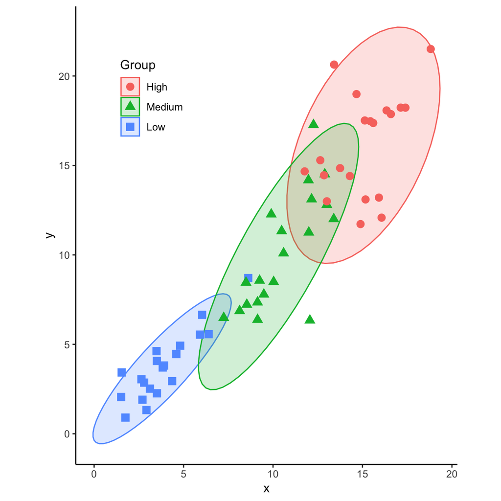

### Exercise 3

The figure for this exercise has width 6 inches and height 6 inches.

Build a dataset to replicate the graphic shown below. The dataset is not randomly generated in this case so an extremely close replication should be possible.

**Hints:**

- The dataset will have three variables: `x`, `y`, and `fill_amount`.
- The graphic works by creating a small **tile** for each `x` and `y` value along the indicated axes and fills the title according to the value supplied by `fill_amount`.
- The structure of the dataset is displayed below. There are 40,401 observations/rows (should realize that each row corresponds to one small tile). By examining the displayed observations it should be clear that `x` values go from -1 to 1 by steps of 0.01. It might not be as obvious, but `y` values also go from -1 to 1 by steps of 0.01. Should make use of `seq()` and `rep()` to create these two columns of the dataset. Examination of the displayed observations and the provided graphic should make clear that the `fill` for each tile is either calculated using $x^3-y$ or $y-x^3$ (should be able to determine which one).
- The **function** can be drawn using the equation provided on the graphic. The color of the **function** is a 50-50 mix of red and blue.
- Getting the superscript on the added text will require setting an option of `parse = TRUE` in the appropriate function/layer.

Below are quick snapshots of the dataset you should create. The first is for rows 1 through 5, second is for rows 197 through 206, and the thrid is for rows 400 through 405. This should help in the construction of the dataset.

```
## # A tibble: 5 x 3
##       x     y fill_amount
##   <dbl> <dbl>       <dbl>
## 1 -1       -1      0
## 2 -0.99    -1      0.0297
## 3 -0.98    -1      0.0588
## 4 -0.97    -1      0.0873
## 5 -0.96    -1      0.115
```

```
## # A tibble: 10 x 3
##        x     y fill_amount
##    <dbl> <dbl>       <dbl>
##  1  0.96 -1         1.88
##  2  0.97 -1         1.91
##  3  0.98 -1         1.94
##  4  0.99 -1         1.97
##  5  1    -1         2
##  6 -1    -0.99     -0.01
##  7 -0.99 -0.99      0.0197
##  8 -0.98 -0.99      0.0488
##  9 -0.97 -0.99      0.0773
## 10 -0.96 -0.99      0.105
```

```
## # A tibble: 6 x 3
##       x     y fill_amount
##   <dbl> <dbl>       <dbl>
## 1  0.98 -0.99     1.93
## 2  0.99 -0.99     1.96
## 3  1    -0.99     1.99
## 4 -1    -0.98    -0.02
## 5 -0.99 -0.98     0.00970
## 6 -0.98 -0.98     0.0388
```

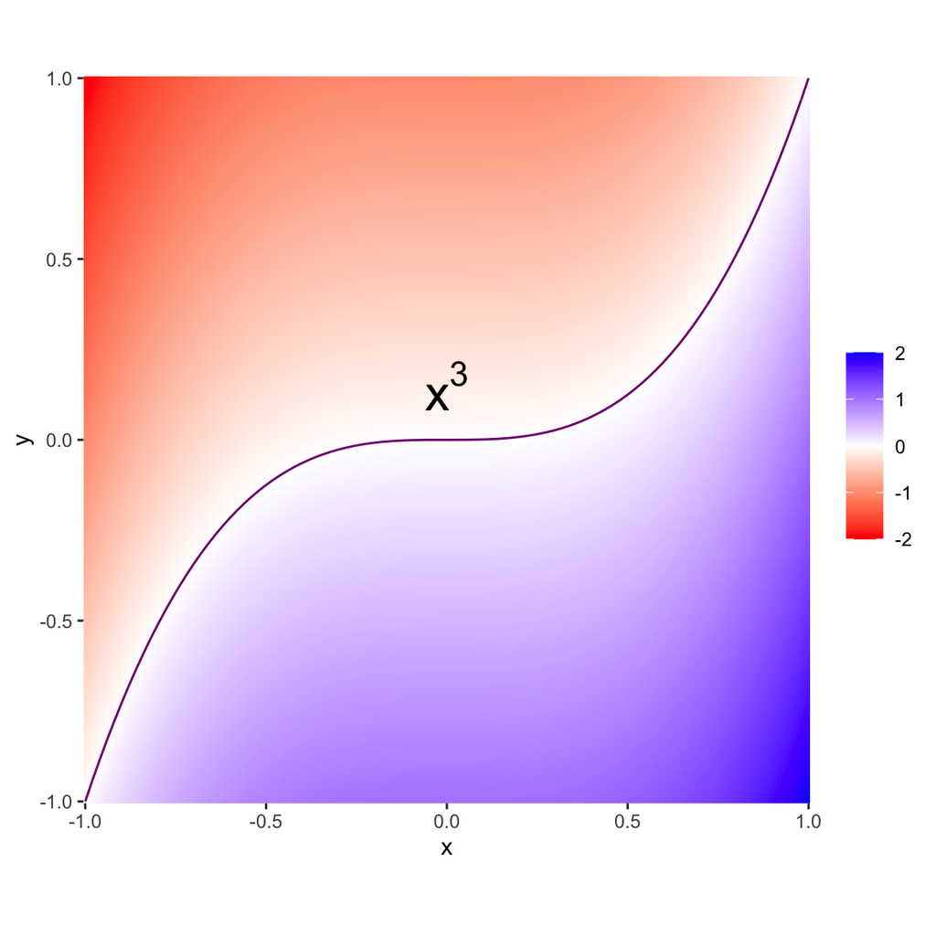